# Risk Factor Analysis

## Outcome Variable

**Outcome Variable:** ever_stunted

## Predictor Variables

**Intervention Variable:** sex

**Adjustment Set:**

unadjusted

## Stratifying Variables

The analysis was stratified on these variable(s):

- agecat
- studyid
- country

## Data Summary

| agecat | studyid | country | sex | ever_stunted | n_cell | n |
| --- | --- | --- | --- | --- | --- | --- |
| 0-24 months | CMC-V-BCS-2002 | INDIA | Female | 0 | 13 | 373 |
| 0-24 months | CMC-V-BCS-2002 | INDIA | Female | 1 | 174 | 373 |
| 0-24 months | CMC-V-BCS-2002 | INDIA | Male | 0 | 15 | 373 |
| 0-24 months | CMC-V-BCS-2002 | INDIA | Male | 1 | 171 | 373 |
| 0-24 months | CMIN | BANGLADESH | Female | 0 | 18 | 277 |
| 0-24 months | CMIN | BANGLADESH | Female | 1 | 102 | 277 |
| 0-24 months | CMIN | BANGLADESH | Male | 0 | 23 | 277 |
| 0-24 months | CMIN | BANGLADESH | Male | 1 | 134 | 277 |
| 0-24 months | COHORTS | GUATEMALA | Female | 0 | 158 | 1368 |
| 0-24 months | COHORTS | GUATEMALA | Female | 1 | 486 | 1368 |
| 0-24 months | COHORTS | GUATEMALA | Male | 0 | 165 | 1368 |
| 0-24 months | COHORTS | GUATEMALA | Male | 1 | 559 | 1368 |
| 0-24 months | COHORTS | INDIA | Female | 0 | 2321 | 7417 |
| 0-24 months | COHORTS | INDIA | Female | 1 | 1233 | 7417 |
| 0-24 months | COHORTS | INDIA | Male | 0 | 2346 | 7417 |
| 0-24 months | COHORTS | INDIA | Male | 1 | 1517 | 7417 |
| 0-24 months | COHORTS | PHILIPPINES | Female | 0 | 488 | 3058 |
| 0-24 months | COHORTS | PHILIPPINES | Female | 1 | 949 | 3058 |
| 0-24 months | COHORTS | PHILIPPINES | Male | 0 | 471 | 3058 |
| 0-24 months | COHORTS | PHILIPPINES | Male | 1 | 1150 | 3058 |
| 0-24 months | CONTENT | PERU | Female | 0 | 87 | 215 |
| 0-24 months | CONTENT | PERU | Female | 1 | 22 | 215 |
| 0-24 months | CONTENT | PERU | Male | 0 | 75 | 215 |
| 0-24 months | CONTENT | PERU | Male | 1 | 31 | 215 |
| 0-24 months | EE | PAKISTAN | Female | 0 | 21 | 379 |
| 0-24 months | EE | PAKISTAN | Female | 1 | 164 | 379 |
| 0-24 months | EE | PAKISTAN | Male | 0 | 20 | 379 |
| 0-24 months | EE | PAKISTAN | Male | 1 | 174 | 379 |
| 0-24 months | GMS-Nepal | NEPAL | Female | 0 | 113 | 698 |
| 0-24 months | GMS-Nepal | NEPAL | Female | 1 | 215 | 698 |

[output cut: 214 more lines]

The following strata were considered:

- agecat: 0-24 months, studyid: CMC-V-BCS-2002, country: INDIA
- agecat: 0-24 months, studyid: CMIN, country: BANGLADESH
- agecat: 0-24 months, studyid: COHORTS, country: GUATEMALA
- agecat: 0-24 months, studyid: COHORTS, country: INDIA
- agecat: 0-24 months, studyid: COHORTS, country: PHILIPPINES
- agecat: 0-24 months, studyid: CONTENT, country: PERU
- agecat: 0-24 months, studyid: EE, country: PAKISTAN
- agecat: 0-24 months, studyid: GMS-Nepal, country: NEPAL
- agecat: 0-24 months, studyid: Guatemala BSC, country: GUATEMALA
- agecat: 0-24 months, studyid: iLiNS-Zinc, country: BURKINA FASO
- agecat: 0-24 months, studyid: IRC, country: INDIA
- agecat: 0-24 months, studyid: JiVitA-3, country: BANGLADESH
- agecat: 0-24 months, studyid: JiVitA-4, country: BANGLADESH
- agecat: 0-24 months, studyid: Keneba, country: GAMBIA
- agecat: 0-24 months, studyid: LCNI-5, country: MALAWI
- agecat: 0-24 months, studyid: MAL-ED, country: BANGLADESH
- agecat: 0-24 months, studyid: MAL-ED, country: BRAZIL
- agecat: 0-24 months, studyid: MAL-ED, country: INDIA
- agecat: 0-24 months, studyid: MAL-ED, country: NEPAL
- agecat: 0-24 months, studyid: MAL-ED, country: PERU
- agecat: 0-24 months, studyid: MAL-ED, country: SOUTH AFRICA
- agecat: 0-24 months, studyid: MAL-ED, country: TANZANIA, UNITED REPUBLIC OF
- agecat: 0-24 months, studyid: NIH-Birth, country: BANGLADESH
- agecat: 0-24 months, studyid: NIH-Crypto, country: BANGLADESH
- agecat: 0-24 months, studyid: PROBIT, country: BELARUS
- agecat: 0-24 months, studyid: PROVIDE, country: BANGLADESH
- agecat: 0-24 months, studyid: ResPak, country: PAKISTAN
- agecat: 0-24 months, studyid: SAS-CompFeed, country: INDIA
- agecat: 0-24 months, studyid: SAS-FoodSuppl, country: INDIA
- agecat: 0-24 months, studyid: TanzaniaChild2, country: TANZANIA, UNITED REPUBLIC OF
- agecat: 0-24 months, studyid: ZVITAMBO, country: ZIMBABWE
- agecat: 0-6 months, studyid: CMC-V-BCS-2002, country: INDIA
- agecat: 0-6 months, studyid: CMIN, country: BANGLADESH
- agecat: 0-6 months, studyid: COHORTS, country: GUATEMALA
- agecat: 0-6 months, studyid: COHORTS, country: INDIA
- agecat: 0-6 months, studyid: COHORTS, country: PHILIPPINES
- agecat: 0-6 months, studyid: CONTENT, country: PERU
- agecat: 0-6 months, studyid: EE, country: PAKISTAN
- agecat: 0-6 months, studyid: GMS-Nepal, country: NEPAL
- agecat: 0-6 months, studyid: Guatemala BSC, country: GUATEMALA
- agecat: 0-6 months, studyid: IRC, country: INDIA
- agecat: 0-6 months, studyid: JiVitA-3, country: BANGLADESH
- agecat: 0-6 months, studyid: JiVitA-4, country: BANGLADESH
- agecat: 0-6 months, studyid: Keneba, country: GAMBIA
- agecat: 0-6 months, studyid: LCNI-5, country: MALAWI
- agecat: 0-6 months, studyid: MAL-ED, country: BANGLADESH
- agecat: 0-6 months, studyid: MAL-ED, country: BRAZIL
- agecat: 0-6 months, studyid: MAL-ED, country: INDIA
- agecat: 0-6 months, studyid: MAL-ED, country: NEPAL
- agecat: 0-6 months, studyid: MAL-ED, country: PERU
- agecat: 0-6 months, studyid: MAL-ED, country: SOUTH AFRICA
- agecat: 0-6 months, studyid: MAL-ED, country: TANZANIA, UNITED REPUBLIC OF
- agecat: 0-6 months, studyid: NIH-Birth, country: BANGLADESH
- agecat: 0-6 months, studyid: NIH-Crypto, country: BANGLADESH
- agecat: 0-6 months, studyid: PROBIT, country: BELARUS
- agecat: 0-6 months, studyid: PROVIDE, country: BANGLADESH
- agecat: 0-6 months, studyid: ResPak, country: PAKISTAN
- agecat: 0-6 months, studyid: SAS-CompFeed, country: INDIA
- agecat: 0-6 months, studyid: SAS-FoodSuppl, country: INDIA
- agecat: 0-6 months, studyid: TanzaniaChild2, country: TANZANIA, UNITED REPUBLIC OF
- agecat: 0-6 months, studyid: ZVITAMBO, country: ZIMBABWE

## Methods Detail

We're interested in the causal parameters $E[Y_a]$ for all values of $a \in \mathcal{A}$. These parameters represent the mean outcome if, possibly contrary to fact, we intervened to set all units to have $A=a$. Under the randomization and positivity assumptions, these are identified by the statistical parameters $\psi_a=E_W[E_{Y|A,W}(Y|A=a,W)]$. In addition, we're interested in the mean of $Y$, $E[Y]$ under no intervention (the observed mean). We will estimate these parameters by using SuperLearner to fit the relevant likelihood factors -- $E_{Y|A,W}(Y|A=a,W)$ and $p(A=a|W)$, and then updating our likelihood fit using a joint TMLE.

For unadjusted analyses ($W=\{\}$), initial likelihoods were estimated using Lrnr_glm to estimate the simple $E(Y|A)$ and Lrnr_mean to estimate $p(A)$. For adjusted analyses, a small library containing Lrnr_glmnet, Lrnr_xgboost, and Lrnr_mean was used.

Having estimated these parameters, we will then use the delta method to estimate relative risks and attributable risks relative to a prespecified baseline level of $A$.

# Results Detail

## Results Plots

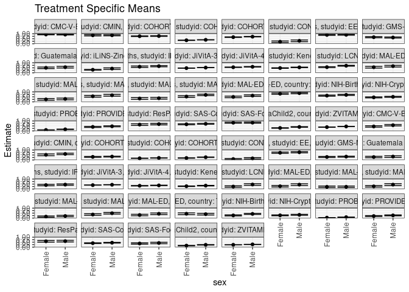

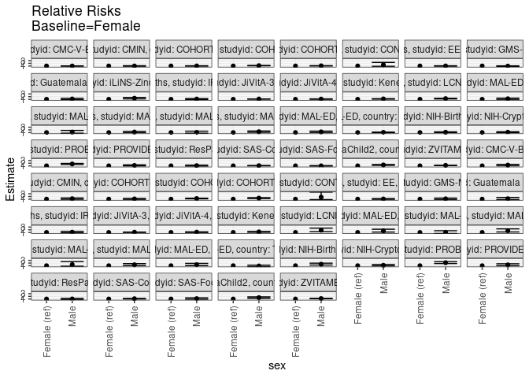

[figure not shown]

[figure not shown]

## Results Table

### Parameter: TSM

| agecat | studyid | country | intervention_level | baseline_level | estimate | ci_lower | ci_upper |
| --- | --- | --- | --- | --- | --- | --- | --- |
| 0-24 months | CMC-V-BCS-2002 | INDIA | Female | NA | 0.9304813 | 0.8939794 | 0.9669831 |
| 0-24 months | CMC-V-BCS-2002 | INDIA | Male | NA | 0.9193548 | 0.8801712 | 0.9585385 |
| 0-24 months | CMIN | BANGLADESH | Female | NA | 0.8500000 | 0.7859974 | 0.9140026 |
| 0-24 months | CMIN | BANGLADESH | Male | NA | 0.8535032 | 0.7980916 | 0.9089147 |
| 0-24 months | COHORTS | GUATEMALA | Female | NA | 0.7546584 | 0.7214135 | 0.7879033 |
| 0-24 months | COHORTS | GUATEMALA | Male | NA | 0.7720994 | 0.7415329 | 0.8026660 |
| 0-24 months | COHORTS | INDIA | Female | NA | 0.3469330 | 0.3312828 | 0.3625832 |
| 0-24 months | COHORTS | INDIA | Male | NA | 0.3927000 | 0.3772990 | 0.4081009 |
| 0-24 months | COHORTS | PHILIPPINES | Female | NA | 0.6604036 | 0.6359143 | 0.6848930 |
| 0-24 months | COHORTS | PHILIPPINES | Male | NA | 0.7094386 | 0.6873329 | 0.7315443 |
| 0-24 months | CONTENT | PERU | Female | NA | 0.2018349 | 0.1263097 | 0.2773600 |
| 0-24 months | CONTENT | PERU | Male | NA | 0.2924528 | 0.2056542 | 0.3792515 |
| 0-24 months | EE | PAKISTAN | Female | NA | 0.8864865 | 0.8407149 | 0.9322581 |
| 0-24 months | EE | PAKISTAN | Male | NA | 0.8969072 | 0.8540614 | 0.9397531 |
| 0-24 months | GMS-Nepal | NEPAL | Female | NA | 0.6554878 | 0.6040234 | 0.7069522 |
| 0-24 months | GMS-Nepal | NEPAL | Male | NA | 0.6243243 | 0.5749421 | 0.6737065 |
| 0-24 months | Guatemala BSC | GUATEMALA | Female | NA | 0.5000000 | 0.4228828 | 0.5771172 |
| 0-24 months | Guatemala BSC | GUATEMALA | Male | NA | 0.5620915 | 0.4833528 | 0.6408302 |
| 0-24 months | iLiNS-Zinc | BURKINA FASO | Female | NA | 0.3027692 | 0.2666148 | 0.3389237 |
| 0-24 months | iLiNS-Zinc | BURKINA FASO | Male | NA | 0.4213415 | 0.3442350 | 0.4984479 |
| 0-24 months | IRC | INDIA | Female | NA | 0.6108108 | 0.5404669 | 0.6811547 |
| 0-24 months | IRC | INDIA | Male | NA | 0.6666667 | 0.6049957 | 0.7283376 |
| 0-24 months | JiVitA-3 | BANGLADESH | Female | NA | 0.4695724 | 0.4596472 | 0.4794975 |
| 0-24 months | JiVitA-3 | BANGLADESH | Male | NA | 0.5201790 | 0.5099437 | 0.5304144 |
| 0-24 months | JiVitA-4 | BANGLADESH | Female | NA | 0.5583700 | 0.5369431 | 0.5797969 |
| 0-24 months | JiVitA-4 | BANGLADESH | Male | NA | 0.6041207 | 0.5818153 | 0.6264261 |
| 0-24 months | Keneba | GAMBIA | Female | NA | 0.4776119 | 0.4515078 | 0.5037161 |
| 0-24 months | Keneba | GAMBIA | Male | NA | 0.5450928 | 0.5199555 | 0.5702301 |
| 0-24 months | LCNI-5 | MALAWI | Female | NA | 0.5653207 | 0.5179404 | 0.6127009 |
| 0-24 months | LCNI-5 | MALAWI | Male | NA | 0.7088305 | 0.6653050 | 0.7523561 |

[output cut: 92 more lines]

### Parameter: E(Y)

| agecat | studyid | country | intervention_level | baseline_level | estimate | ci_lower | ci_upper |
| --- | --- | --- | --- | --- | --- | --- | --- |
| 0-24 months | CMC-V-BCS-2002 | INDIA | NA | NA | 0.9249330 | 0.8981563 | 0.9517096 |
| 0-24 months | CMIN | BANGLADESH | NA | NA | 0.8519856 | 0.8100906 | 0.8938805 |
| 0-24 months | COHORTS | GUATEMALA | NA | NA | 0.7638889 | 0.7413757 | 0.7864021 |
| 0-24 months | COHORTS | INDIA | NA | NA | 0.3707699 | 0.3597768 | 0.3817630 |
| 0-24 months | COHORTS | PHILIPPINES | NA | NA | 0.6863963 | 0.6699497 | 0.7028430 |
| 0-24 months | CONTENT | PERU | NA | NA | 0.2465116 | 0.1887688 | 0.3042545 |
| 0-24 months | EE | PAKISTAN | NA | NA | 0.8918206 | 0.8605084 | 0.9231328 |
| 0-24 months | GMS-Nepal | NEPAL | NA | NA | 0.6389685 | 0.6033115 | 0.6746254 |
| 0-24 months | Guatemala BSC | GUATEMALA | NA | NA | 0.5301587 | 0.4749558 | 0.5853616 |
| 0-24 months | iLiNS-Zinc | BURKINA FASO | NA | NA | 0.3623277 | 0.3130786 | 0.4115769 |
| 0-24 months | IRC | INDIA | NA | NA | 0.6414634 | 0.5949863 | 0.6879405 |
| 0-24 months | JiVitA-3 | BANGLADESH | NA | NA | 0.4953171 | 0.4874955 | 0.5031388 |
| 0-24 months | JiVitA-4 | BANGLADESH | NA | NA | 0.5812201 | 0.5652281 | 0.5972122 |
| 0-24 months | Keneba | GAMBIA | NA | NA | 0.5125214 | 0.4943731 | 0.5306698 |
| 0-24 months | LCNI-5 | MALAWI | NA | NA | 0.6369048 | 0.6043650 | 0.6694445 |
| 0-24 months | MAL-ED | BANGLADESH | NA | NA | 0.6113208 | 0.5525209 | 0.6701206 |
| 0-24 months | MAL-ED | BRAZIL | NA | NA | 0.2703863 | 0.2132328 | 0.3275398 |
| 0-24 months | MAL-ED | INDIA | NA | NA | 0.6055777 | 0.5449957 | 0.6661597 |
| 0-24 months | MAL-ED | NEPAL | NA | NA | 0.3500000 | 0.2895300 | 0.4104700 |
| 0-24 months | MAL-ED | PERU | NA | NA | 0.6204620 | 0.5657315 | 0.6751926 |
| 0-24 months | MAL-ED | SOUTH AFRICA | NA | NA | 0.5605096 | 0.5055248 | 0.6154943 |
| 0-24 months | MAL-ED | TANZANIA, UNITED REPUBLIC OF | NA | NA | 0.8473282 | 0.8036934 | 0.8909630 |
| 0-24 months | NIH-Birth | BANGLADESH | NA | NA | 0.6645469 | 0.6276196 | 0.7014742 |
| 0-24 months | NIH-Crypto | BANGLADESH | NA | NA | 0.4775726 | 0.4419904 | 0.5131548 |
| 0-24 months | PROBIT | BELARUS | NA | NA | 0.1274191 | 0.1115552 | 0.1432829 |
| 0-24 months | PROVIDE | BANGLADESH | NA | NA | 0.4357143 | 0.3989556 | 0.4724730 |
| 0-24 months | ResPak | PAKISTAN | NA | NA | 0.6584507 | 0.6031993 | 0.7137021 |
| 0-24 months | SAS-CompFeed | INDIA | NA | NA | 0.6914547 | 0.6510509 | 0.7318584 |
| 0-24 months | SAS-FoodSuppl | INDIA | NA | NA | 0.8277512 | 0.7915095 | 0.8639929 |
| 0-24 months | TanzaniaChild2 | TANZANIA, UNITED REPUBLIC OF | NA | NA | 0.3459933 | 0.3269422 | 0.3650444 |
| 0-24 months | ZVITAMBO | ZIMBABWE | NA | NA | 0.4171522 | 0.4090055 | 0.4252989 |
| 0-6 months | CMC-V-BCS-2002 | INDIA | NA | NA | 0.5108696 | 0.4597270 | 0.5620121 |
| 0-6 months | CMIN | BANGLADESH | NA | NA | 0.5667870 | 0.5083276 | 0.6252464 |
| 0-6 months | COHORTS | GUATEMALA | NA | NA | 0.3260073 | 0.2981925 | 0.3538222 |
| 0-6 months | COHORTS | INDIA | NA | NA | 0.1864548 | 0.1774430 | 0.1954667 |
| 0-6 months | COHORTS | PHILIPPINES | NA | NA | 0.2390451 | 0.2239262 | 0.2541640 |
| 0-6 months | CONTENT | PERU | NA | NA | 0.1255814 | 0.0811834 | 0.1699794 |
| 0-6 months | EE | PAKISTAN | NA | NA | 0.7493404 | 0.7056502 | 0.7930306 |
| 0-6 months | GMS-Nepal | NEPAL | NA | NA | 0.3180516 | 0.2834770 | 0.3526261 |
| 0-6 months | Guatemala BSC | GUATEMALA | NA | NA | 0.3152542 | 0.2621451 | 0.3683634 |
| 0-6 months | IRC | INDIA | NA | NA | 0.4243902 | 0.3764905 | 0.4722900 |
| 0-6 months | JiVitA-3 | BANGLADESH | NA | NA | 0.4129818 | 0.4055453 | 0.4204184 |
| 0-6 months | JiVitA-4 | BANGLADESH | NA | NA | 0.3477583 | 0.3325749 | 0.3629416 |
| 0-6 months | Keneba | GAMBIA | NA | NA | 0.3123732 | 0.2940736 | 0.3306728 |
| 0-6 months | LCNI-5 | MALAWI | NA | NA | 0.3566176 | 0.2995882 | 0.4136471 |
| 0-6 months | MAL-ED | BANGLADESH | NA | NA | 0.3584906 | 0.3006428 | 0.4163383 |
| 0-6 months | MAL-ED | BRAZIL | NA | NA | 0.2231760 | 0.1695976 | 0.2767543 |
| 0-6 months | MAL-ED | INDIA | NA | NA | 0.3466135 | 0.2876225 | 0.4056046 |
| 0-6 months | MAL-ED | NEPAL | NA | NA | 0.1791667 | 0.1305478 | 0.2277856 |
| 0-6 months | MAL-ED | PERU | NA | NA | 0.4257426 | 0.3699763 | 0.4815088 |
| 0-6 months | MAL-ED | SOUTH AFRICA | NA | NA | 0.3694268 | 0.3159570 | 0.4228965 |
| 0-6 months | MAL-ED | TANZANIA, UNITED REPUBLIC OF | NA | NA | 0.4160305 | 0.3562327 | 0.4758284 |
| 0-6 months | NIH-Birth | BANGLADESH | NA | NA | 0.3497615 | 0.3124631 | 0.3870600 |
| 0-6 months | NIH-Crypto | BANGLADESH | NA | NA | 0.3021108 | 0.2694011 | 0.3348205 |
| 0-6 months | PROBIT | BELARUS | NA | NA | 0.0686124 | 0.0577768 | 0.0794479 |
| 0-6 months | PROVIDE | BANGLADESH | NA | NA | 0.2400000 | 0.2083392 | 0.2716608 |
| 0-6 months | ResPak | PAKISTAN | NA | NA | 0.5957447 | 0.5383657 | 0.6531237 |
| 0-6 months | SAS-CompFeed | INDIA | NA | NA | 0.4254902 | 0.3977202 | 0.4532601 |
| 0-6 months | SAS-FoodSuppl | INDIA | NA | NA | 0.3894231 | 0.3425088 | 0.4363374 |
| 0-6 months | TanzaniaChild2 | TANZANIA, UNITED REPUBLIC OF | NA | NA | 0.1949082 | 0.1790434 | 0.2107729 |
| 0-6 months | ZVITAMBO | ZIMBABWE | NA | NA | 0.2586612 | 0.2514220 | 0.2659004 |

### Parameter: RR

| agecat | studyid | country | intervention_level | baseline_level | estimate | ci_lower | ci_upper |
| --- | --- | --- | --- | --- | --- | --- | --- |
| 0-24 months | CMC-V-BCS-2002 | INDIA | Female | Female | 1.0000000 | 1.0000000 | 1.000000 |
| 0-24 months | CMC-V-BCS-2002 | INDIA | Male | Female | 0.9880423 | 0.9324348 | 1.046966 |
| 0-24 months | CMIN | BANGLADESH | Female | Female | 1.0000000 | 1.0000000 | 1.000000 |
| 0-24 months | CMIN | BANGLADESH | Male | Female | 1.0041214 | 0.9090925 | 1.109084 |
| 0-24 months | COHORTS | GUATEMALA | Female | Female | 1.0000000 | 1.0000000 | 1.000000 |
| 0-24 months | COHORTS | GUATEMALA | Male | Female | 1.0231112 | 0.9642741 | 1.085538 |
| 0-24 months | COHORTS | INDIA | Female | Female | 1.0000000 | 1.0000000 | 1.000000 |
| 0-24 months | COHORTS | INDIA | Male | Female | 1.1319187 | 1.0662413 | 1.201642 |
| 0-24 months | COHORTS | PHILIPPINES | Female | Female | 1.0000000 | 1.0000000 | 1.000000 |
| 0-24 months | COHORTS | PHILIPPINES | Male | Female | 1.0742500 | 1.0234581 | 1.127563 |
| 0-24 months | CONTENT | PERU | Female | Female | 1.0000000 | 1.0000000 | 1.000000 |
| 0-24 months | CONTENT | PERU | Male | Female | 1.4489708 | 0.8987478 | 2.336046 |
| 0-24 months | EE | PAKISTAN | Female | Female | 1.0000000 | 1.0000000 | 1.000000 |
| 0-24 months | EE | PAKISTAN | Male | Female | 1.0117551 | 0.9430319 | 1.085487 |
| 0-24 months | GMS-Nepal | NEPAL | Female | Female | 1.0000000 | 1.0000000 | 1.000000 |
| 0-24 months | GMS-Nepal | NEPAL | Male | Female | 0.9524576 | 0.8520094 | 1.064748 |
| 0-24 months | Guatemala BSC | GUATEMALA | Female | Female | 1.0000000 | 1.0000000 | 1.000000 |
| 0-24 months | Guatemala BSC | GUATEMALA | Male | Female | 1.1241830 | 0.9127469 | 1.384598 |
| 0-24 months | iLiNS-Zinc | BURKINA FASO | Female | Female | 1.0000000 | 1.0000000 | 1.000000 |
| 0-24 months | iLiNS-Zinc | BURKINA FASO | Male | Female | 1.3916258 | 1.1468171 | 1.688693 |
| 0-24 months | IRC | INDIA | Female | Female | 1.0000000 | 1.0000000 | 1.000000 |
| 0-24 months | IRC | INDIA | Male | Female | 1.0914454 | 0.9415628 | 1.265187 |
| 0-24 months | JiVitA-3 | BANGLADESH | Female | Female | 1.0000000 | 1.0000000 | 1.000000 |
| 0-24 months | JiVitA-3 | BANGLADESH | Male | Female | 1.1077718 | 1.0795127 | 1.136771 |
| 0-24 months | JiVitA-4 | BANGLADESH | Female | Female | 1.0000000 | 1.0000000 | 1.000000 |
| 0-24 months | JiVitA-4 | BANGLADESH | Male | Female | 1.0819360 | 1.0279020 | 1.138810 |
| 0-24 months | Keneba | GAMBIA | Female | Female | 1.0000000 | 1.0000000 | 1.000000 |
| 0-24 months | Keneba | GAMBIA | Male | Female | 1.1412881 | 1.0625229 | 1.225892 |
| 0-24 months | LCNI-5 | MALAWI | Female | Female | 1.0000000 | 1.0000000 | 1.000000 |
| 0-24 months | LCNI-5 | MALAWI | Male | Female | 1.2538557 | 1.1301213 | 1.391137 |

[output cut: 92 more lines]

### Parameter: PAR

| agecat | studyid | country | intervention_level | baseline_level | estimate | ci_lower | ci_upper |
| --- | --- | --- | --- | --- | --- | --- | --- |
| 0-24 months | CMC-V-BCS-2002 | INDIA | Female | NA | -0.0055483 | -0.0322582 | 0.0211616 |
| 0-24 months | CMIN | BANGLADESH | Female | NA | 0.0019856 | -0.0459973 | 0.0499684 |
| 0-24 months | COHORTS | GUATEMALA | Female | NA | 0.0092305 | -0.0146751 | 0.0331361 |
| 0-24 months | COHORTS | INDIA | Female | NA | 0.0238368 | 0.0123890 | 0.0352846 |
| 0-24 months | COHORTS | PHILIPPINES | Female | NA | 0.0259927 | 0.0084833 | 0.0435021 |
| 0-24 months | CONTENT | PERU | Female | NA | 0.0446768 | -0.0123727 | 0.1017263 |
| 0-24 months | EE | PAKISTAN | Female | NA | 0.0053341 | -0.0267627 | 0.0374309 |
| 0-24 months | GMS-Nepal | NEPAL | Female | NA | -0.0165193 | -0.0543451 | 0.0213064 |
| 0-24 months | Guatemala BSC | GUATEMALA | Female | NA | 0.0301587 | -0.0234831 | 0.0838005 |
| 0-24 months | iLiNS-Zinc | BURKINA FASO | Female | NA | 0.0595585 | 0.0178371 | 0.1012799 |
| 0-24 months | IRC | INDIA | Female | NA | 0.0306526 | -0.0207563 | 0.0820615 |
| 0-24 months | JiVitA-3 | BANGLADESH | Female | NA | 0.0257448 | 0.0192361 | 0.0322534 |
| 0-24 months | JiVitA-4 | BANGLADESH | Female | NA | 0.0228501 | 0.0080013 | 0.0376989 |
| 0-24 months | Keneba | GAMBIA | Female | NA | 0.0349095 | 0.0161219 | 0.0536971 |
| 0-24 months | LCNI-5 | MALAWI | Female | NA | 0.0715841 | 0.0391265 | 0.1040416 |
| 0-24 months | MAL-ED | BANGLADESH | Female | NA | 0.0524972 | -0.0047110 | 0.1097054 |
| 0-24 months | MAL-ED | BRAZIL | Female | NA | 0.0225987 | -0.0362036 | 0.0814009 |
| 0-24 months | MAL-ED | INDIA | Female | NA | 0.0476067 | -0.0070158 | 0.1022292 |
| 0-24 months | MAL-ED | NEPAL | Female | NA | 0.0136364 | -0.0520063 | 0.0792790 |
| 0-24 months | MAL-ED | PERU | Female | NA | 0.0889935 | 0.0309248 | 0.1470623 |
| 0-24 months | MAL-ED | SOUTH AFRICA | Female | NA | 0.0636542 | 0.0093759 | 0.1179325 |
| 0-24 months | MAL-ED | TANZANIA, UNITED REPUBLIC OF | Female | NA | 0.0277794 | -0.0150987 | 0.0706575 |
| 0-24 months | NIH-Birth | BANGLADESH | Female | NA | 0.0416513 | 0.0024984 | 0.0808042 |
| 0-24 months | NIH-Crypto | BANGLADESH | Female | NA | 0.0261290 | -0.0092673 | 0.0615253 |
| 0-24 months | PROBIT | BELARUS | Female | NA | 0.0340906 | 0.0269258 | 0.0412554 |
| 0-24 months | PROVIDE | BANGLADESH | Female | NA | 0.0320998 | -0.0065608 | 0.0707604 |
| 0-24 months | ResPak | PAKISTAN | Female | NA | 0.0260978 | -0.0316185 | 0.0838140 |
| 0-24 months | SAS-CompFeed | INDIA | Female | NA | 0.0257404 | 0.0068649 | 0.0446158 |
| 0-24 months | SAS-FoodSuppl | INDIA | Female | NA | 0.0026391 | -0.0312216 | 0.0364998 |
| 0-24 months | TanzaniaChild2 | TANZANIA, UNITED REPUBLIC OF | Female | NA | 0.0512298 | 0.0319729 | 0.0704868 |
| 0-24 months | ZVITAMBO | ZIMBABWE | Female | NA | 0.0355867 | 0.0272097 | 0.0439638 |
| 0-6 months | CMC-V-BCS-2002 | INDIA | Female | NA | 0.0622209 | 0.0113528 | 0.1130891 |
| 0-6 months | CMIN | BANGLADESH | Female | NA | 0.0501203 | -0.0168810 | 0.1171217 |
| 0-6 months | COHORTS | GUATEMALA | Female | NA | 0.0150668 | -0.0140204 | 0.0441541 |
| 0-6 months | COHORTS | INDIA | Female | NA | 0.0200755 | 0.0108115 | 0.0293396 |
| 0-6 months | COHORTS | PHILIPPINES | Female | NA | 0.0400194 | 0.0240748 | 0.0559640 |
| 0-6 months | CONTENT | PERU | Female | NA | 0.0338383 | -0.0100937 | 0.0777702 |
| 0-6 months | EE | PAKISTAN | Female | NA | 0.0250160 | -0.0197897 | 0.0698218 |
| 0-6 months | GMS-Nepal | NEPAL | Female | NA | 0.0192711 | -0.0173794 | 0.0559215 |
| 0-6 months | Guatemala BSC | GUATEMALA | Female | NA | 0.0230464 | -0.0278698 | 0.0739627 |
| 0-6 months | IRC | INDIA | Female | NA | 0.0243902 | -0.0283523 | 0.0771327 |
| 0-6 months | JiVitA-3 | BANGLADESH | Female | NA | 0.0184342 | 0.0121013 | 0.0247671 |
| 0-6 months | JiVitA-4 | BANGLADESH | Female | NA | 0.0175221 | 0.0029952 | 0.0320491 |
| 0-6 months | Keneba | GAMBIA | Female | NA | 0.0305167 | 0.0115385 | 0.0494949 |
| 0-6 months | LCNI-5 | MALAWI | Female | NA | 0.1085556 | 0.0490635 | 0.1680478 |
| 0-6 months | MAL-ED | BANGLADESH | Female | NA | 0.0790788 | 0.0225494 | 0.1356082 |
| 0-6 months | MAL-ED | BRAZIL | Female | NA | 0.0019370 | -0.0532659 | 0.0571399 |
| 0-6 months | MAL-ED | INDIA | Female | NA | 0.0784976 | 0.0243339 | 0.1326613 |
| 0-6 months | MAL-ED | NEPAL | Female | NA | 0.0337121 | -0.0185090 | 0.0859332 |
| 0-6 months | MAL-ED | PERU | Female | NA | 0.0690992 | 0.0103043 | 0.1278941 |
| 0-6 months | MAL-ED | SOUTH AFRICA | Female | NA | 0.0612507 | 0.0084001 | 0.1141012 |
| 0-6 months | MAL-ED | TANZANIA, UNITED REPUBLIC OF | Female | NA | -0.0200597 | -0.0789403 | 0.0388209 |
| 0-6 months | NIH-Birth | BANGLADESH | Female | NA | 0.0804013 | 0.0412472 | 0.1195553 |
| 0-6 months | NIH-Crypto | BANGLADESH | Female | NA | 0.0238956 | -0.0086502 | 0.0564413 |
| 0-6 months | PROBIT | BELARUS | Female | NA | 0.0253101 | 0.0189683 | 0.0316519 |
| 0-6 months | PROVIDE | BANGLADESH | Female | NA | 0.0351807 | 0.0020226 | 0.0683389 |
| 0-6 months | ResPak | PAKISTAN | Female | NA | 0.0075094 | -0.0519534 | 0.0669722 |
| 0-6 months | SAS-CompFeed | INDIA | Female | NA | 0.0240616 | -0.0017474 | 0.0498707 |
| 0-6 months | SAS-FoodSuppl | INDIA | Female | NA | 0.0245582 | -0.0193781 | 0.0684945 |
| 0-6 months | TanzaniaChild2 | TANZANIA, UNITED REPUBLIC OF | Female | NA | 0.0403474 | 0.0243272 | 0.0563676 |
| 0-6 months | ZVITAMBO | ZIMBABWE | Female | NA | 0.0209983 | 0.0135619 | 0.0284346 |

### Parameter: PAF

| agecat | studyid | country | intervention_level | baseline_level | estimate | ci_lower | ci_upper |
| --- | --- | --- | --- | --- | --- | --- | --- |
| 0-24 months | CMC-V-BCS-2002 | INDIA | Female | NA | -0.0059986 | -0.0353075 | 0.0224806 |
| 0-24 months | CMIN | BANGLADESH | Female | NA | 0.0023305 | -0.0556096 | 0.0570904 |
| 0-24 months | COHORTS | GUATEMALA | Female | NA | 0.0120836 | -0.0197232 | 0.0428983 |
| 0-24 months | COHORTS | INDIA | Female | NA | 0.0642901 | 0.0328930 | 0.0946678 |
| 0-24 months | COHORTS | PHILIPPINES | Female | NA | 0.0378684 | 0.0119649 | 0.0630928 |
| 0-24 months | CONTENT | PERU | Female | NA | 0.1812359 | -0.0838055 | 0.3814623 |
| 0-24 months | EE | PAKISTAN | Female | NA | 0.0059811 | -0.0306783 | 0.0413366 |
| 0-24 months | GMS-Nepal | NEPAL | Female | NA | -0.0258531 | -0.0868416 | 0.0317130 |
| 0-24 months | Guatemala BSC | GUATEMALA | Female | NA | 0.0568862 | -0.0501390 | 0.1530039 |
| 0-24 months | iLiNS-Zinc | BURKINA FASO | Female | NA | 0.1643774 | 0.0571456 | 0.2594136 |
| 0-24 months | IRC | INDIA | Female | NA | 0.0477854 | -0.0360227 | 0.1248140 |
| 0-24 months | JiVitA-3 | BANGLADESH | Female | NA | 0.0519764 | 0.0387596 | 0.0650114 |
| 0-24 months | JiVitA-4 | BANGLADESH | Female | NA | 0.0393140 | 0.0134402 | 0.0645092 |
| 0-24 months | Keneba | GAMBIA | Female | NA | 0.0681132 | 0.0306465 | 0.1041319 |
| 0-24 months | LCNI-5 | MALAWI | Female | NA | 0.1123937 | 0.0592212 | 0.1625609 |
| 0-24 months | MAL-ED | BANGLADESH | Female | NA | 0.0858751 | -0.0134190 | 0.1754404 |
| 0-24 months | MAL-ED | BRAZIL | Female | NA | 0.0835792 | -0.1615766 | 0.2769937 |
| 0-24 months | MAL-ED | INDIA | Female | NA | 0.0786137 | -0.0168376 | 0.1651048 |
| 0-24 months | MAL-ED | NEPAL | Female | NA | 0.0389610 | -0.1681461 | 0.2093490 |
| 0-24 months | MAL-ED | PERU | Female | NA | 0.1434310 | 0.0428320 | 0.2334570 |
| 0-24 months | MAL-ED | SOUTH AFRICA | Female | NA | 0.1135649 | 0.0103420 | 0.2060215 |
| 0-24 months | MAL-ED | TANZANIA, UNITED REPUBLIC OF | Female | NA | 0.0327847 | -0.0194546 | 0.0823471 |
| 0-24 months | NIH-Birth | BANGLADESH | Female | NA | 0.0626762 | 0.0015717 | 0.1200411 |
| 0-24 months | NIH-Crypto | BANGLADESH | Female | NA | 0.0547121 | -0.0224764 | 0.1260735 |
| 0-24 months | PROBIT | BELARUS | Female | NA | 0.2675474 | 0.2099294 | 0.3209635 |
| 0-24 months | PROVIDE | BANGLADESH | Female | NA | 0.0736717 | -0.0195491 | 0.1583691 |
| 0-24 months | ResPak | PAKISTAN | Female | NA | 0.0396351 | -0.0523309 | 0.1235640 |
| 0-24 months | SAS-CompFeed | INDIA | Female | NA | 0.0372264 | 0.0095688 | 0.0641117 |
| 0-24 months | SAS-FoodSuppl | INDIA | Female | NA | 0.0031883 | -0.0385717 | 0.0432691 |
| 0-24 months | TanzaniaChild2 | TANZANIA, UNITED REPUBLIC OF | Female | NA | 0.1480659 | 0.0906135 | 0.2018886 |
| 0-24 months | ZVITAMBO | ZIMBABWE | Female | NA | 0.0853087 | 0.0649833 | 0.1051924 |
| 0-6 months | CMC-V-BCS-2002 | INDIA | Female | NA | 0.1217941 | 0.0156623 | 0.2164828 |
| 0-6 months | CMIN | BANGLADESH | Female | NA | 0.0884289 | -0.0383448 | 0.1997245 |
| 0-6 months | COHORTS | GUATEMALA | Female | NA | 0.0462162 | -0.0473054 | 0.1313866 |
| 0-6 months | COHORTS | INDIA | Female | NA | 0.1076697 | 0.0567457 | 0.1558445 |
| 0-6 months | COHORTS | PHILIPPINES | Female | NA | 0.1674135 | 0.0984030 | 0.2311417 |
| 0-6 months | CONTENT | PERU | Female | NA | 0.2694529 | -0.1625965 | 0.5409422 |
| 0-6 months | EE | PAKISTAN | Female | NA | 0.0333841 | -0.0284585 | 0.0915080 |
| 0-6 months | GMS-Nepal | NEPAL | Female | NA | 0.0605911 | -0.0619827 | 0.1690174 |
| 0-6 months | Guatemala BSC | GUATEMALA | Female | NA | 0.0731043 | -0.1032475 | 0.2212667 |
| 0-6 months | IRC | INDIA | Female | NA | 0.0574713 | -0.0754480 | 0.1739625 |
| 0-6 months | JiVitA-3 | BANGLADESH | Female | NA | 0.0446369 | 0.0292119 | 0.0598167 |
| 0-6 months | JiVitA-4 | BANGLADESH | Female | NA | 0.0503859 | 0.0076480 | 0.0912833 |
| 0-6 months | Keneba | GAMBIA | Female | NA | 0.0976930 | 0.0348979 | 0.1564023 |
| 0-6 months | LCNI-5 | MALAWI | Female | NA | 0.3044034 | 0.1179498 | 0.4514432 |
| 0-6 months | MAL-ED | BANGLADESH | Female | NA | 0.2205882 | 0.0464521 | 0.3629238 |
| 0-6 months | MAL-ED | BRAZIL | Female | NA | 0.0086794 | -0.2722615 | 0.2275829 |
| 0-6 months | MAL-ED | INDIA | Female | NA | 0.2264701 | 0.0543474 | 0.3672639 |
| 0-6 months | MAL-ED | NEPAL | Female | NA | 0.1881607 | -0.1583457 | 0.4310135 |
| 0-6 months | MAL-ED | PERU | Female | NA | 0.1623028 | 0.0117010 | 0.2899552 |
| 0-6 months | MAL-ED | SOUTH AFRICA | Female | NA | 0.1657992 | 0.0097926 | 0.2972270 |
| 0-6 months | MAL-ED | TANZANIA, UNITED REPUBLIC OF | Female | NA | -0.0482169 | -0.1998418 | 0.0842471 |
| 0-6 months | NIH-Birth | BANGLADESH | Female | NA | 0.2298745 | 0.1099176 | 0.3336647 |
| 0-6 months | NIH-Crypto | BANGLADESH | Female | NA | 0.0790955 | -0.0351089 | 0.1806996 |
| 0-6 months | PROBIT | BELARUS | Female | NA | 0.3688855 | 0.2952891 | 0.4347958 |
| 0-6 months | PROVIDE | BANGLADESH | Female | NA | 0.1465863 | -0.0026496 | 0.2736098 |
| 0-6 months | ResPak | PAKISTAN | Female | NA | 0.0126050 | -0.0924423 | 0.1075512 |
| 0-6 months | SAS-CompFeed | INDIA | Female | NA | 0.0565504 | -0.0061560 | 0.1153487 |
| 0-6 months | SAS-FoodSuppl | INDIA | Female | NA | 0.0630631 | -0.0568914 | 0.1694030 |
| 0-6 months | TanzaniaChild2 | TANZANIA, UNITED REPUBLIC OF | Female | NA | 0.2070071 | 0.1215899 | 0.2841182 |
| 0-6 months | ZVITAMBO | ZIMBABWE | Female | NA | 0.0811806 | 0.0520099 | 0.1094536 |